# Fallstudie Tips - Vorhersagen mit linearen Modellen

Manfred Brill

# Der Datensatz Tips

Der Datensatz enthält Angaben über Trinkgelder in einem US-amerikanischen Familienrestaurant aus den neunziger Jahren. Ursprünglich stammen die Daten aus (Bryant and Smith 2003). Der Datensatz wird in vielen Büchern zur Statistik und Datenanalyse. Die vorliegende Darstellung folgt (Swayne 2007) und (Martin Theus 2009), die Daten stammen von der Website zu (Swayne 2007). In einem Markdown-File haben wir die Daten eingelesen, eine Menge von Visualisierungen erstellt und ein weiteres Merkmal *Trinkgeldrate* erzeugt. Diesen neuen Datensatz lesen wir mit *read_csv2* ein, er stellt die Basis für die Betrachtung von Modellen für die Vorhersage des Trinkgelds dar. Zur Überprüfung verwenden wir *kable* und geben die ersten Zeilen der eingelesenen Daten aus.

```r
daten <- read_csv2("data/tipsWithRate.csv")
```

```
i Using "','" as decimal and "'.'" as grouping mark. Use `read_delim()` for more control.
```

```r
kable(head(daten), align="l",
      caption="Tabelle 1: Die ersten Werte im Datensatz Tips") %>%
      kable_styling(bootstrap_options = c("striped", "condensed"),
                full_width = T,
                position = "center")
```

Tabelle 1: Die ersten Werte im Datensatz Tips

| Rechnung | Trinkgeld | Trinkgeldrate | Geschlecht | Raucher | Wochentag | Tageszeit | Anzahl |
| --- | --- | --- | --- | --- | --- | --- | --- |
| 17.0 | 1.01 | 0.059 | Frau | Nein | Sonntag | Abend | 2 |
| 10.3 | 1.66 | 0.161 | Mann | Nein | Sonntag | Abend | 3 |
| 21.0 | 3.50 | 0.167 | Mann | Nein | Sonntag | Abend | 3 |
| 23.7 | 3.31 | 0.140 | Mann | Nein | Sonntag | Abend | 2 |
| 24.6 | 3.61 | 0.147 | Frau | Nein | Sonntag | Abend | 4 |
| 25.3 | 4.71 | 0.186 | Mann | Nein | Sonntag | Abend | 4 |

# Streuungsdiagramme

Wir erstellen einige Streuungsdiagramme, um einen möglichen Zusammenhang zwischen den Merkmalen und der Trinkgeldrate zu überprüfen.

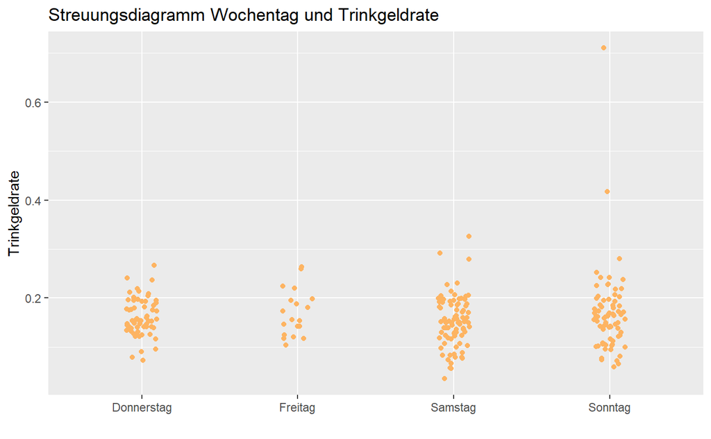

```r
ggplot(daten,
       aes(x=Wochentag, y=Trinkgeldrate)) +
  geom_jitter(color=myPalette[6],
             show.legend=FALSE,
             width=0.1,
             height=0.0) +
  scale_x_discrete(limits=c("Donnerstag", "Freitag", "Samstag", "Sonntag"),
                   breaks = c("Donnerstag", "Freitag", "Samstag", "Sonntag")) +
  labs(
         title="Streuungsdiagramm Wochentag und Trinkgeldrate",
         x="",
         y="Trinkgeldrate"
  )

ggsave(filename="tipsTagRate.png", plot=last_plot(),
       device="png",
       path="images/",
       width=16,
       height=9,
       units="cm")
```

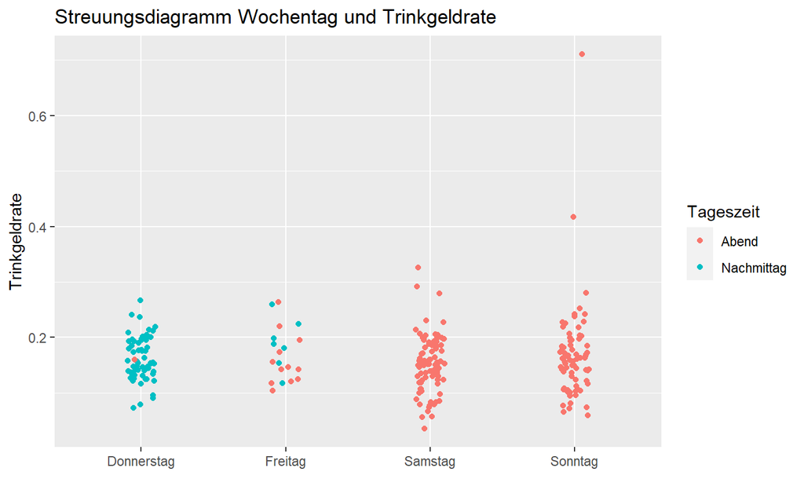

```r
ggplot(daten,
       aes(x=Wochentag, y=Trinkgeldrate, color=Tageszeit)) +
  geom_jitter(show.legend=TRUE,
              width=0.1,
              height=0.0) +
  scale_x_discrete(limits=c("Donnerstag", "Freitag", "Samstag", "Sonntag"),
                   breaks = c("Donnerstag", "Freitag", "Samstag", "Sonntag")) +
  labs(
         title="Streuungsdiagramm Wochentag und Trinkgeldrate",
         x="",
         y="Trinkgeldrate"
  )

ggsave(filename="tipsTagRateTageszeit.png", plot=last_plot(),
       device="png",
       path="images/",
       width=16,
       height=9,
       units="cm")
```

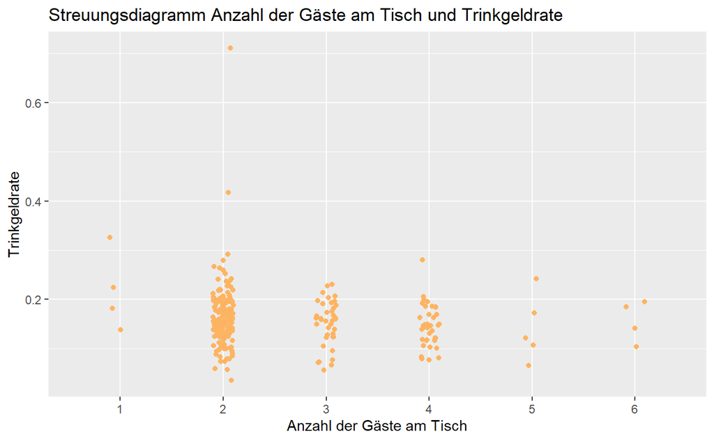

```r
ggplot(daten,
       aes(x=Anzahl, y=Trinkgeldrate)) +
  geom_jitter(color=myPalette[6],
             show.legend=FALSE,
             width=0.1,
             height=0.0) +
  scale_x_discrete(limits=seq(1,6),
                   breaks=seq(1,6)) +
  labs(
         title="Streuungsdiagramm Anzahl der Gäste am Tisch und Trinkgeldrate",
         x="Anzahl der Gäste am Tisch",
         y="Trinkgeldrate"
  )
ggsave(filename="tipsAnzahlRate.png", plot=last_plot(),
       device="png",
       path="images/",
       width=16,
       height=9,
       units="cm")
```

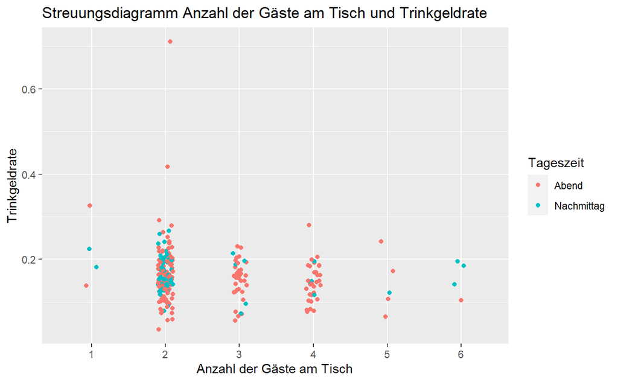

```r
ggplot(daten,
       aes(x=Anzahl, y=Trinkgeldrate, color=Tageszeit)) +
  geom_jitter(width=0.1,
              height=0.0) +
  scale_x_discrete(limits=seq(1,6),
                   breaks=seq(1,6)) +
  labs(
         title="Streuungsdiagramm Anzahl der Gäste am Tisch und Trinkgeldrate",
         x="Anzahl der Gäste am Tisch",
         y="Trinkgeldrate"
  )
ggsave(filename="tipsAnzahlRateTageszeit.png", plot=last_plot(),
       device="png",
       path="images/",
       width=16,
       height=9,
       units="cm")
```

# Lineare Modelle

In der Literatur wird ein lineares Modell vorgeschlagen, das aus der Anzahl der Personen am Tisch die Trinkgeldrate vorhersagt. Wir betrachten im ersten Schritt dieses Modell.

## Lineare Modelle mit geom_smooth

Im ersten Schritt nutzen wir *geom_smooth*, mit dessen Hilfe wir die Ausgleichsgerade direkt mit *ggplot* ausgeben können. Dabei können wir auch Konfidenzintervalle für das berechnete Modell ausgeben.

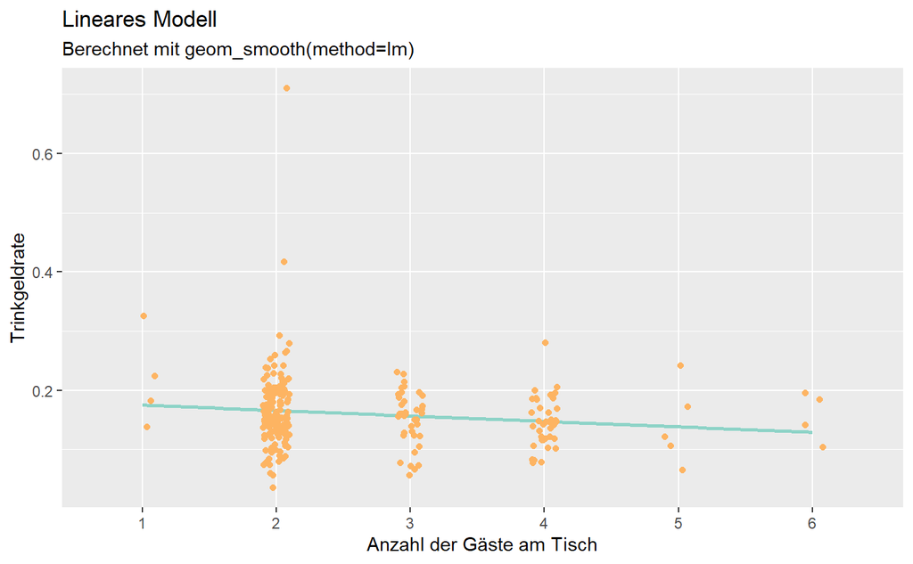

```r
ggplot(daten,
       aes(x=Anzahl, y=Trinkgeldrate)) +
  geom_smooth(method=lm,
              formula = y ~ x,
              se=FALSE,
              color=myPalette[1],
              size=1,
              fullrange = TRUE) +
  geom_jitter(color=myPalette[6],
              show.legend=FALSE,
              width = 0.1) +
  scale_x_discrete(limits=seq(1,6),
                   breaks=seq(1,6)) +
  labs(
         title="Lineares Modell",
         subtitle="Berechnet mit geom_smooth(method=lm)",
         x="Anzahl der Gäste am Tisch",
         y="Trinkgeldrate"
  )
ggsave(filename="tipsggsmooth.png", plot=last_plot(),
       device="png",
       path="images/",
       width=16,
       height=9,
       units="cm")
```

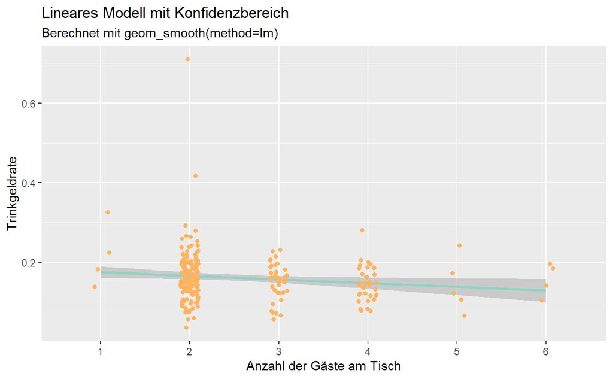

```r
# Mit Fehler-Bereich
ggplot(daten,
       aes(x=Anzahl, y=Trinkgeldrate)) +
  geom_smooth(method=lm,
              se=TRUE,
              color=myPalette[1],
              size = 1) +
  geom_jitter(color=myPalette[6],
             show.legend=FALSE,
             width=0.1,
             height=0.0) +
  scale_x_discrete(limits=seq(1,6),
                   breaks=seq(1,6)) +
  labs(
         title="Lineares Modell mit Konfidenzbereich",
         subtitle="Berechnet mit geom_smooth(method=lm)",
         x="Anzahl der Gäste am Tisch",
         y="Trinkgeldrate"
  )
ggsave(filename="tipsggsmoothConf.png", plot=last_plot(),
       device="png",
       path="images/",
       width=16,
       height=9,
       units="cm")
```

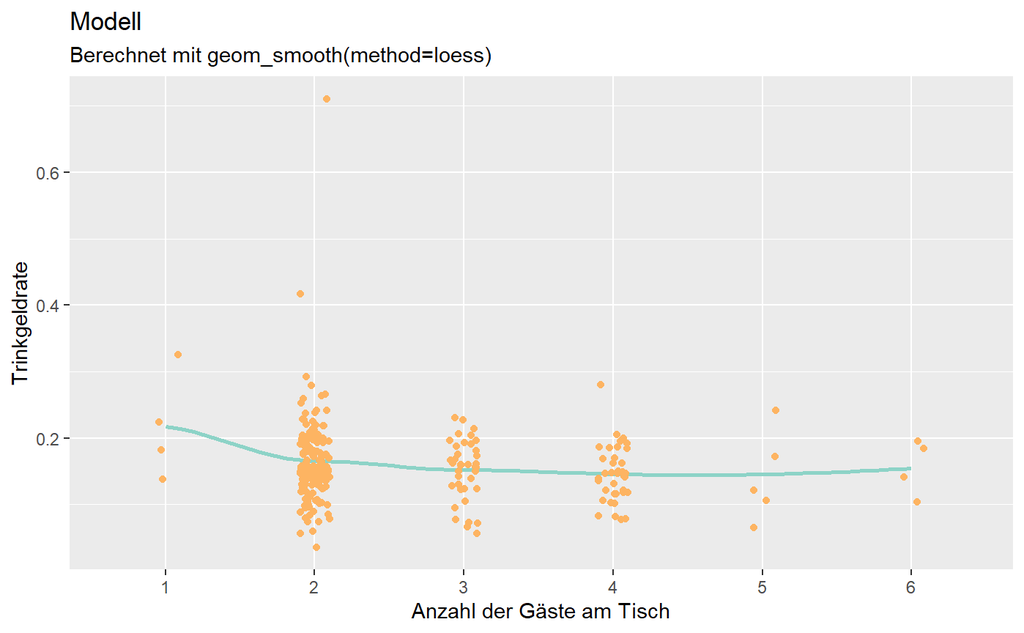

```r
ggplot(daten,
       aes(x=Anzahl, y=Trinkgeldrate)) +
  geom_smooth(method=loess,
              formula = y ~ x,
              se=FALSE,
              color=myPalette[1],
              size=1,
              fullrange = TRUE) +
  geom_jitter(color=myPalette[6],
              show.legend=FALSE,
              width = 0.1) +
  scale_x_discrete(limits=seq(1,6),
                   breaks=seq(1,6)) +
  labs(
         title="Modell",
         subtitle="Berechnet mit geom_smooth(method=loess)",
         x="Anzahl der Gäste am Tisch",
         y="Trinkgeldrate"
  )
ggsave(filename="tipsggsmoothLoess.png", plot=last_plot(),
       device="png",
       path="images/",
       width=16,
       height=9,
       units="cm")
```

## Lineare Modelle mit lm

Wir verwenden Funktionen wie lm oder glm, berechnen das Modell und stellen die Ergebnisse in der Grafik mit geoms wie *geom_abline* dar.

```r
linearModel <- lm(Trinkgeldrate ~ Anzahl, data = daten)

linearModel.ab <- coef(linearModel)
linearModel.summary <- summary(linearModel)
linearModel.res <- linearModel.summary$residuals
```

Die berechnete Steigung für das lineare Modell ist -0.009. Der Achsenabschnitt ist 0.184. Das Bestimmungsmaß ist 0.02, also nicht sehr hoch.

Die Ausgaben der Funktion *summary* geben eine ausführliche Diagnose aus, da uns insbesondere die p-Werte interessieren.

```r
linearModel.summary
```

```
Call:
lm(formula = Trinkgeldrate ~ Anzahl, data = daten)

Residuals:
    Min      1Q  Median      3Q     Max
-0.1304 -0.0308 -0.0061  0.0315  0.5443

Coefficients:
            Estimate Std. Error t value Pr(>|t|)
(Intercept)  0.18438    0.01119   16.47   <2e-16 ***
Anzahl      -0.00917    0.00409   -2.25    0.026 *
---
Signif. codes:
0 ‘***’ 0.001 ‘**’ 0.01 ‘*’ 0.05 ‘.’ 0.1 ‘ ’ 1

Residual standard error: 0.0606 on 242 degrees of freedom
Multiple R-squared:  0.0204,    Adjusted R-squared:  0.0164
F-statistic: 5.04 on 1 and 242 DF,  p-value: 0.0256
```

Jetzt können wir die in *linearModel.ab* gespeicherten Koeffizienten der berechneten Gerade verwenden und geben die Gerade im Streuungsdiagramm mit *geom_abline* mit aus.

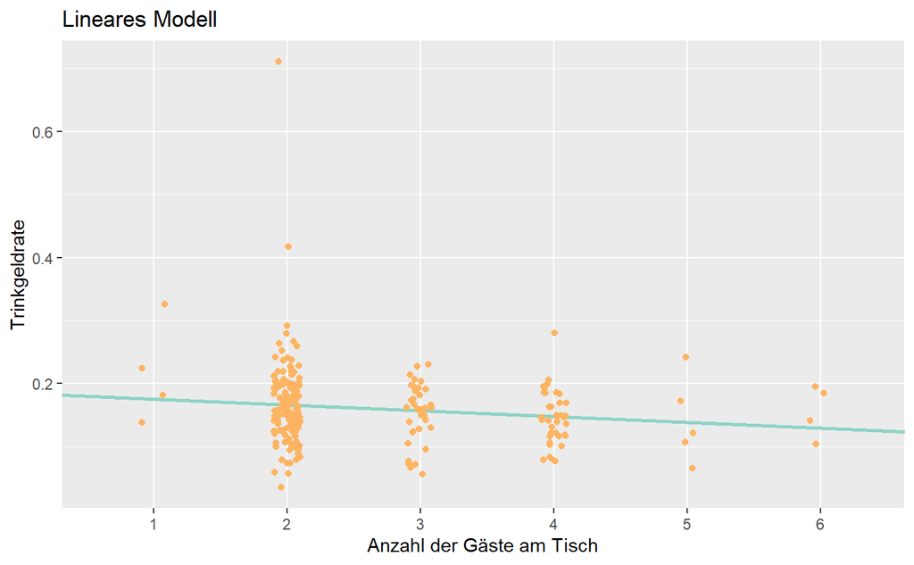

```r
ggplot(daten,
       aes(x=Anzahl, y=Trinkgeldrate)
       ) +
  geom_abline(aes(intercept=linearModel.ab[1], slope=linearModel.ab[2]),
              color=myPalette[1],
              size=1.0) +
  geom_jitter(color=myPalette[6],
             show.legend=FALSE,
             width=0.1,
             height=0.0) +
  scale_x_discrete(limits=seq(1,6),
                   breaks=seq(1,6)) +
  labs(
         title="Lineares Modell",
         x="Anzahl der Gäste am Tisch",
         y="Trinkgeldrate"
  )
ggsave(filename="tipsabLine.png", plot=last_plot(),
       device="png",
       path="images/",
       width=16,
       height=9,
       units="cm")
```

Wir fügen jetzt unserem Datensatz die Residuen hinzu und geben einen Residualplot aus. Wir könnten dies aus der Variablen *linearModel* ablesen, aber wir verwenden das Package *modelr* aus *tidyverse* und die Funktion *add_residuals*. Wir erhalten eine weitere Spalte in unserem Datensatz mit dem Bezeichner *resid*.

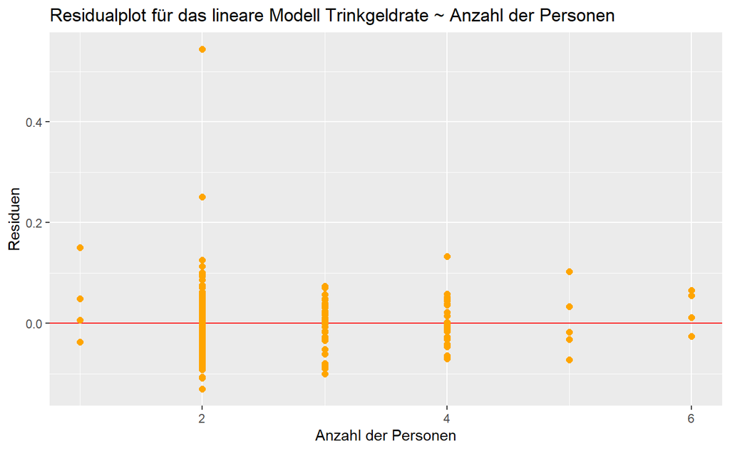

```r
daten1 <- daten %>%
  add_residuals(linearModel)

# Residualplot
ggplot(daten1, aes(Anzahl, resid)) +
  geom_ref_line(h=0,
                colour = "red",
                size = 0.5) +
  geom_point(size=2.0, color="orange") +
  labs(
    title="Residualplot für das lineare Modell Trinkgeldrate ~ Anzahl der Personen",
    x="Anzahl der Personen",
    y="Residuen"
  )

ggsave(filename="tipsResid.png", plot=last_plot(),
       device="png",
       path="images/",
       width=16,
       height=9,
       units="cm")
```

```r
# Wir erzeugen die Werte, die wir einsetzen als data.frame
persons <- tibble(Anzahl = c(4,6,7,8))
```

Wir erzeugen jetzt einige Vorhersagen mit Hilfe der Funktion *predict*. Die Anzahl der Personen, für die wir die Vorhersagen machen möchten speichern wir in einem Tibble ab. Wir betrachten Vorhersagen für 4, 6, 7 und 8 Personen.

```r
# Wir setzen das berechnete Modell und die neuen Werte in predict ein
linearModel.predictions <- predict(linearModel, persons)
```

# Empfehlungen für Trinkgelder

Wir machen jetzt Vorhersagen für eine verschiedene Anzahlen von Personen und an einem Tisch und einer Rechnungshöhe. Das lineare Modell sagt für eine Anzahl die Trinkgeldrate voraus, aus der wir mit der Rechnungshöhe das Trinkgeld empfehlen.

```r
tip.prediction <- persons %>%
  mutate(
    Rechnung = c(10.0, 20.0, 30.0, 30.0),
    Trinkgeldrate = linearModel.predictions,
    Trinkgeldempfehlung = Trinkgeldrate * Rechnung
  ) %>%
  select(Anzahl, Rechnung, Trinkgeldempfehlung)

kable(tip.prediction,
      align="l",
      caption="Tabelle 2: Empfehlungen für das Trinkgeld auf der Basis des linearen Modells Anzahl ~ Trinkgeldrate",
            col.names=c("Anzahl der Personen", "Rechnungshöhe", "Empfohlenes Trinkgeld")) %>%
      kable_styling(
        bootstrap_options = c("striped", "condensed"),
       full_width = T,
       position = "center")
```

Tabelle 2: Empfehlungen für das Trinkgeld auf der Basis des linearen Modells Anzahl ~ Trinkgeldrate

| Anzahl der Personen | Rechnungshöhe | Empfohlenes Trinkgeld |
| --- | --- | --- |
| 4 | 10 | 1.48 |
| 6 | 20 | 2.59 |
| 7 | 30 | 3.60 |
| 8 | 30 | 3.33 |

# Weitere lineare Modelle

Wir können uns natürlich fragen, ob das in der Literatur vorgeschlagene Modell wirklich die beste Lösung ist. Deshalb werden wir in diesem Abschnitt noch weitere Modelle erstellen und gegenseitig vergleichen.

## Vorhersagen mit Hilfe der Merkmale Rechnungshöhe

Wir könnten natürlich statt mit dem neu eingeführten Merkmal *Trinkgeldrate* eine Empfehlung direkt aus der Rechnungshöhe berechnen.

```r
linearModel2 <- lm(Trinkgeld ~ Rechnung, data = daten)

linearModel2.ab <- coef(linearModel2)
linearModel2.summary <- summary(linearModel2)
linearModel2.res <- linearModel2.summary$residuals

linearModel2.summary
```

```
Call:
lm(formula = Trinkgeld ~ Rechnung, data = daten)

Residuals:
   Min     1Q Median     3Q    Max
-3.198 -0.565 -0.097  0.486  3.743

Coefficients:
            Estimate Std. Error t value Pr(>|t|)
(Intercept)  0.92027    0.15973    5.76  2.5e-08 ***
Rechnung     0.10502    0.00736   14.26  < 2e-16 ***
---
Signif. codes:
0 ‘***’ 0.001 ‘**’ 0.01 ‘*’ 0.05 ‘.’ 0.1 ‘ ’ 1

Residual standard error: 1.02 on 242 degrees of freedom
Multiple R-squared:  0.457, Adjusted R-squared:  0.454
F-statistic:  203 on 1 and 242 DF,  p-value: <2e-16
```

Die berechnete Steigung für das lineare Modell ist 0.105. Der Achsenabschnitt ist 0.92. Das Bestimmungsmaß ist 0.457. Wir erhalten eine deutlich höheres Bestimmungsmaß als für das Modell aus der Literatur. Wir erstellen eine grafische Darstellung dieses Modells in einem Streuungsdiagramm.

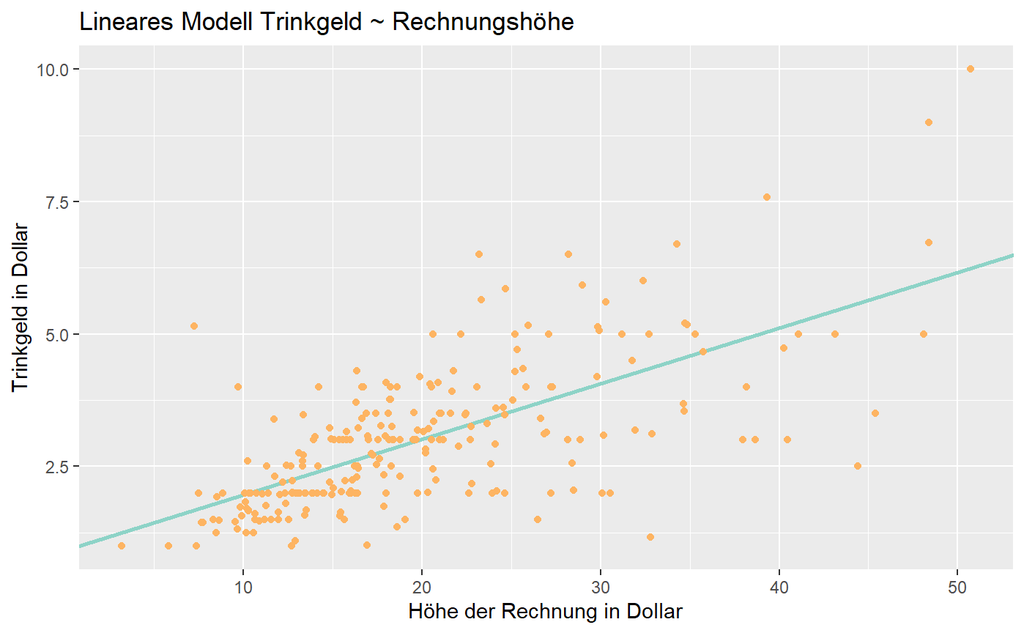

```r
ggplot(daten,
       aes(x=Rechnung, y=Trinkgeld)
       ) +
  geom_abline(aes(intercept=linearModel2.ab[1], slope=linearModel2.ab[2]),
              color=myPalette[1],
              size=1.0) +
  geom_jitter(color=myPalette[6],
             show.legend=FALSE,
             width=0.1,
             height=0.0) +
  labs(
         title="Lineares Modell Trinkgeld ~ Rechnungshöhe",
         x="Höhe der Rechnung in Dollar",
         y="Trinkgeld in Dollar"
  )

ggsave(filename="tipsabLine2.png", plot=last_plot(),
       device="png",
       path="images/",
       width=16,
       height=9,
       units="cm")
```

```r
bills <- tibble(Rechnung = c(10.0, 20.0, 30.0, 30.0))

linearModel2.predictions <- predict(linearModel2, bills)

tip2.prediction <- bills %>%
  mutate(
    Trinkgeld = linearModel2.predictions
  )

kable(tip2.prediction,
      align="l",
      caption="Tabelle 3: Empfehlungen für das Trinkgeld auf der Basis des linearen Modells Trinkgeld ~ Rechnungshöhe",
            col.names=c("Rechnung in Dollar", "Empfohlenes Trinkgeld in Dollar")) %>%
      kable_styling(
        bootstrap_options = c("striped", "condensed"),
       full_width = T,
       position = "center")
```

Tabelle 3: Empfehlungen für das Trinkgeld auf der Basis des linearen Modells Trinkgeld ~ Rechnungshöhe

| Rechnung in Dollar | Empfohlenes Trinkgeld in Dollar |
| --- | --- |
| 10 | 1.97 |
| 20 | 3.02 |
| 30 | 4.07 |
| 30 | 4.07 |

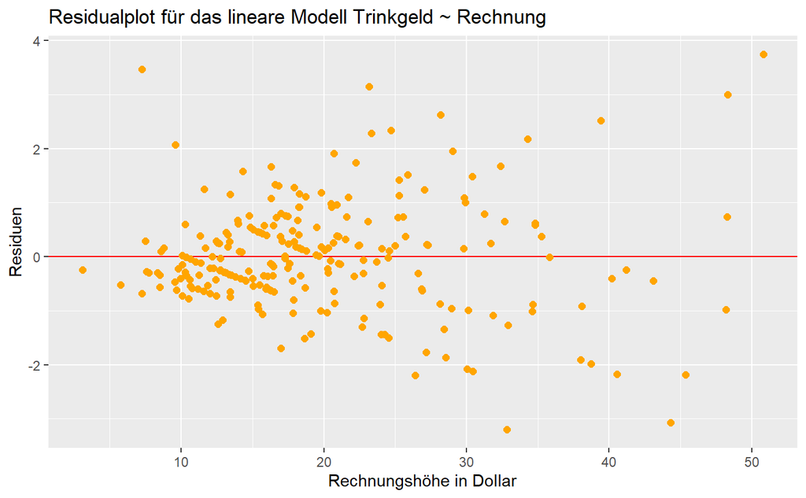

```r
daten2 <- daten %>%
  add_residuals(linearModel2)

# Residualplot
ggplot(daten2, aes(Rechnung, resid)) +
  geom_ref_line(h=0,
                colour = "red",
                size = 0.5) +
  geom_point(size=2.0, color="orange") +
  labs(
    title="Residualplot für das lineare Modell Trinkgeld ~ Rechnung",
    x="Rechnungshöhe in Dollar",
    y="Residuen"
  )

ggsave(filename="tipsResid2.png", plot=last_plot(),
       device="png",
       path="images/",
       width=16,
       height=9,
       units="cm")
```

```r
rm(daten2)
```

Der Residualplot für dieses Modell sieht, bis auf einige Ausreißer für sehr kleinen und sehr großen Rechnungshöhen, ebenfalls gut aus, so dass wir jetzt ein zweites lineares Modell für die Vorhersage des Trinkgelds haben. Wir vergleichen nochmals beide Vorhersagen in einer Tabelle.

```r
predictions <- tibble(tip.prediction$Rechnung,
                      tip.prediction$Trinkgeldempfehlung,
                      tip2.prediction$Trinkgeld)
kable(predictions,
      align="l",
      caption="Tabelle 4: Empfehlungen für das Trinkgeld",
            col.names=c("Rechnungshöhe in Dollar", "Trinkgeld-Empfehlung Modell 1 in Dollar", "Trinkgeld-Empfehlung Modell 2 in Dollar")) %>%
      kable_styling(
        bootstrap_options = c("striped", "condensed"),
       full_width = T,
       position = "center")
```

Tabelle 4: Empfehlungen für das Trinkgeld

| Rechnungshöhe in Dollar | Trinkgeld-Empfehlung Modell 1 in Dollar | Trinkgeld-Empfehlung Modell 2 in Dollar |
| --- | --- | --- |
| 10 | 1.48 | 1.97 |
| 20 | 2.59 | 3.02 |
| 30 | 3.60 | 4.07 |
| 30 | 3.33 | 4.07 |

Bereits diese Tabelle zeigt uns, dass das Modell *Rechnung ~ Trinkgeld* deutlich höhere Empfehlungen ausgibt.

## Ein multilineares Modell

Bevor wir einen Blick darauf werfen, wie wir verschiedenen Modelle vergleichen uns eine Entscheidung treffen, welches wir letztendlich verwenden, erstellen wir ein weiteres Modell. Wir können lineare Modelle mit mehr als einem Einflussfaktor aufbauen. Dann ist es nicht mehr ganz so leicht die Ergebnisse zu visualisieren, aber es liegt nahe beide bisher erstellten Modelle zu kombinieren und sowohl die Anzahl der Personen und die Rechnungshöhe in ein Modell einzubauen.

```r
multiModel1 <- lm(Trinkgeld ~ Anzahl+Rechnung, data = daten)

multiModel1.ab <- coef(multiModel1)
multiModel1.summary <- summary(multiModel1)

multiModel1.summary
```

```
Call:
lm(formula = Trinkgeld ~ Anzahl + Rechnung, data = daten)

Residuals:
   Min     1Q Median     3Q    Max
-2.928 -0.555 -0.085  0.509  4.042

Coefficients:
            Estimate Std. Error t value Pr(>|t|)
(Intercept)  0.66894    0.19361    3.46  0.00065 ***
Anzahl       0.19260    0.08531    2.26  0.02487 *
Rechnung     0.09271    0.00911   10.17  < 2e-16 ***
---
Signif. codes:
0 ‘***’ 0.001 ‘**’ 0.01 ‘*’ 0.05 ‘.’ 0.1 ‘ ’ 1

Residual standard error: 1.01 on 241 degrees of freedom
Multiple R-squared:  0.468, Adjusted R-squared:  0.463
F-statistic:  106 on 2 and 241 DF,  p-value: <2e-16
```

Vergleicht man die Bestimmungsmaße für die Modelle *Trinkgeld ~ Rechnung* und Trinkgeld ~ Rechnung + Anzahl*, dann erkennt man, dass der Wert für das Modell mit zwei Merkmalen leicht höher ist. Das ist zu erwarten - je mehr Merkmale wir in einem Modell haben, desto höher ist das Bestimmungsmaß. Es stellt sich nur die Frage, wie hoch der Unterschied zwischen beiden Werten ist.

# Auswahl der Merkmale für ein Modell

Wir haben bisher drei Modelle erstellt, darunter ein multilineares Modell. Im machine learning gibt es verschiedene Strategien, wie man eine Entscheidung trifft, welche Merkmale letztendlich in das verwendete Modell eingehen sollen. Wir könnten natürlich auf die Idee kommen *alle* möglichen Kombinationen aufzubauen und dann zu vergleichen. Das ist aber keine gute Idee, denn die Kombinatorik sagt uns, dass dies viel zu viele Möglichkeiten sein werden. Deshalb gibt es insgesamt drei Strategien, wie wir solche Merkmale auswählen. Die Darstellung folgt dabei (Gareth et al. 2013) auf den Seiten 78 und 79. Bevor wir die drei Strategien beschreiben müssen wir uns klar machen, dass wir natürlich auf jeden Fall ein Kriterium benötigen. Häufig legen wir einen p-Wert für ein Merkmal fest, der nicht überschritten werden darf.

## Forward Selection

1. Wir beginnen mit einem *Null-Modell*, das kein Einflussgröße und nur einen Achsenabschnitt enthält. Mit anderen Worten wir verwenden eine konstante Vorhersage.
2. Anschließend erstellen wir für alle p Einflussgrößen in den Daten ein lineares Modell und untersuchen die Fehler und die Bestimmungsmaße für diese Modelle.
3. Wir fügen das *beste* Merkmal aus diesen p Modellen zu unserem Modell hinzu.
4. Anschließend wiederholen wir das Vorgehen und erstellen ein multilineares Modell, indem wir jedes der verbleibenden p-1 Merkmale hinzufügen und wählen wieder das beste davon aus. Wir überprüfen, ob wir abbrechen, falls nicht, wiederholen wir diese Schritte, bis wir ein Modell erreicht haben, das wir verwenden.

## Backward Selection

1. Wir beginnen mit allen Merkmalen im Datensatz und erstellen ein multilineares Modell, das alle Merkmale enthält.
2. Wir betrachten die p-Werte dieser Merkmale und entfernen das Merkmal aus dem Modell, das den größten p-Wert enthält (falls es p-Werte gibt, die oberhalb unserer gewählten Schranke liegen).
3. Wir erstellen ein Modell mit den verbliebenen p-1 Merkmalen und gehen wie im vorherigen Schritt vor.
4. Dies führen wir durch, bis ein Abbruchkriterium erreicht ist.

## Mixed Selection

Dieses Vorgehen ist ein Kombination aus forward und backward selection.

1. Wir beginnen mit dem Null-Modell, also keine Einflussgrößen.
2. Wir fügen wie in der forward selection das beste Modell mit einer Einflussgröße hinzu.
3. Wir fügen sukzessive weitere Merkmale hinzu. Sollte es ein Merkmal geben, dessen p-Wert unser Kriterium verletzt, entfernen wir dieses Merkmal aus unserem Modell.
4. Wir fügen sukzessive die verbliebenen Merkmale hinzu.

Ergebnis dieses Vorgehens ist ein Modell, das nur die Merkmale enthält, die von uns akzeptierte p-Werte aufweisen.

## Backward Selection für die Vorhersage von Trinkgeldern.

```r
pV <- 0.0001
```

```r
multiModel.Full <- lm(Trinkgeld ~ ., data = daten)

multiModel.Full.ab <- coef(multiModel.Full )
multiModel.Full.summary <- summary(multiModel.Full )

multiModel.Full.summary
```

```
Call:
lm(formula = Trinkgeld ~ ., data = daten)

Residuals:
   Min     1Q Median     3Q    Max
-3.971 -0.160  0.017  0.226  2.308

Coefficients:
                    Estimate Std. Error t value Pr(>|t|)
(Intercept)         -2.41442    0.31261   -7.72  3.3e-13
Rechnung             0.13633    0.00562   24.24  < 2e-16
Trinkgeldrate       14.83318    0.64375   23.04  < 2e-16
GeschlechtMann       0.03538    0.07855    0.45    0.653
RaucherNein          0.27124    0.08164    3.32    0.001
WochentagFreitag     0.05387    0.21810    0.25    0.805
WochentagSamstag    -0.02235    0.26086   -0.09    0.932
WochentagSonntag    -0.18913    0.26183   -0.72    0.471
TageszeitNachmittag -0.03326    0.24648   -0.13    0.893
Anzahl               0.08227    0.04979    1.65    0.100

(Intercept)         ***
Rechnung            ***
Trinkgeldrate       ***
GeschlechtMann
RaucherNein         **
WochentagFreitag
WochentagSamstag
WochentagSonntag
TageszeitNachmittag
Anzahl              .
---
Signif. codes:
0 ‘***’ 0.001 ‘**’ 0.01 ‘*’ 0.05 ‘.’ 0.1 ‘ ’ 1

Residual standard error: 0.568 on 234 degrees of freedom
Multiple R-squared:  0.838, Adjusted R-squared:  0.832
F-statistic:  134 on 9 and 234 DF,  p-value: <2e-16
```

Das Ergebnis zeigt uns, dass eigentlich nur drei Merkmale übrig bleiben. Dabei enthalten die Daten sowohl die Rechnungshöhe als auch die Trinkgeldrate, die natürlich voneinander abhängen. Um dies zu kompensieren erstellen wir zwei Varianten unserer Daten und wiederholen unser Experiment.

```r
daten.Orig <- daten %>%
  select(-Trinkgeldrate)

multiModel.Full1 <- lm(Trinkgeld ~ ., data = daten.Orig)

summary(multiModel.Full1)
```

```
Call:
lm(formula = Trinkgeld ~ ., data = daten.Orig)

Residuals:
   Min     1Q Median     3Q    Max
-2.848 -0.573 -0.103  0.476  4.108

Coefficients:
                    Estimate Std. Error t value Pr(>|t|)
(Intercept)           0.5552     0.5139    1.08    0.281
Rechnung              0.0945     0.0096    9.84   <2e-16
GeschlechtMann       -0.0324     0.1416   -0.23    0.819
RaucherNein           0.0864     0.1466    0.59    0.556
WochentagFreitag      0.1623     0.3934    0.41    0.680
WochentagSamstag      0.0408     0.4706    0.09    0.931
WochentagSonntag      0.1368     0.4717    0.29    0.772
TageszeitNachmittag   0.0681     0.4446    0.15    0.878
Anzahl                0.1760     0.0895    1.97    0.051

(Intercept)
Rechnung            ***
GeschlechtMann
RaucherNein
WochentagFreitag
WochentagSamstag
WochentagSonntag
TageszeitNachmittag
Anzahl              .
---
Signif. codes:
0 ‘***’ 0.001 ‘**’ 0.01 ‘*’ 0.05 ‘.’ 0.1 ‘ ’ 1

Residual standard error: 1.02 on 235 degrees of freedom
Multiple R-squared:  0.47,  Adjusted R-squared:  0.452
F-statistic: 26.1 on 8 and 235 DF,  p-value: <2e-16
```

Jetzt bleibt eigentlich nur die Rechnungshöhe als signifikanter Einflussfaktor übrig. Am höchsten sind die p-Werte für die Wochentage, so dass wir jetzt ein Modell bauen ohne dieses Merkmal.

```r
multiModel.Full11 <- lm(Trinkgeld ~ .-Wochentag, data = daten.Orig)

summary(multiModel.Full11)
```

```
Call:
lm(formula = Trinkgeld ~ . - Wochentag, data = daten.Orig)

Residuals:
   Min     1Q Median     3Q    Max
-2.892 -0.572 -0.059  0.499  4.066

Coefficients:
                    Estimate Std. Error t value Pr(>|t|)
(Intercept)          0.64135    0.23162    2.77   0.0061
Rechnung             0.09407    0.00950    9.90   <2e-16
GeschlechtMann      -0.02811    0.14005   -0.20   0.8411
RaucherNein          0.08390    0.13870    0.60   0.5458
TageszeitNachmittag -0.00495    0.15070   -0.03   0.9738
Anzahl               0.18027    0.08816    2.04   0.0420

(Intercept)         **
Rechnung            ***
GeschlechtMann
RaucherNein
TageszeitNachmittag
Anzahl              *
---
Signif. codes:
0 ‘***’ 0.001 ‘**’ 0.01 ‘*’ 0.05 ‘.’ 0.1 ‘ ’ 1

Residual standard error: 1.02 on 238 degrees of freedom
Multiple R-squared:  0.469, Adjusted R-squared:  0.458
F-statistic:   42 on 5 and 238 DF,  p-value: <2e-16
```

Das Bestimmungsmaß wird leicht kleiner, aber nur um sehr wenig. Wir können vermuten, dass wir auch das Merkmal Tageszeit entfernen können, was wir auch tun.

```r
multiModel.Full12 <- lm(Trinkgeld ~ .-Wochentag-Tageszeit, data = daten.Orig)

summary(multiModel.Full12)
```

```
Call:
lm(formula = Trinkgeld ~ . - Wochentag - Tageszeit, data = daten.Orig)

Residuals:
   Min     1Q Median     3Q    Max
-2.892 -0.574 -0.059  0.500  4.066

Coefficients:
               Estimate Std. Error t value Pr(>|t|)
(Intercept)     0.63878    0.21753    2.94   0.0036 **
Rechnung        0.09411    0.00941   10.00   <2e-16 ***
GeschlechtMann -0.02726    0.13737   -0.20   0.8428
RaucherNein     0.08371    0.13828    0.61   0.5455
Anzahl          0.18028    0.08798    2.05   0.0415 *
---
Signif. codes:
0 ‘***’ 0.001 ‘**’ 0.01 ‘*’ 0.05 ‘.’ 0.1 ‘ ’ 1

Residual standard error: 1.02 on 239 degrees of freedom
Multiple R-squared:  0.469, Adjusted R-squared:  0.46
F-statistic: 52.7 on 4 and 239 DF,  p-value: <2e-16
```

Das machen wir jetzt weiter und entfernen sukzessive das Merkmal Geschlecht und auch Raucher.

```r
multiModel.Full13 <- lm(Trinkgeld ~ .-Wochentag -Tageszeit - Geschlecht, data = daten.Orig)

summary(multiModel.Full13)
```

```
Call:
lm(formula = Trinkgeld ~ . - Wochentag - Tageszeit - Geschlecht,
    data = daten.Orig)

Residuals:
   Min     1Q Median     3Q    Max
-2.899 -0.570 -0.064  0.511  4.063

Coefficients:
            Estimate Std. Error t value Pr(>|t|)
(Intercept)  0.62558    0.20671    3.03   0.0027 **
Rechnung     0.09389    0.00933   10.06   <2e-16 ***
RaucherNein  0.08343    0.13800    0.60   0.5460
Anzahl       0.18033    0.08780    2.05   0.0411 *
---
Signif. codes:
0 ‘***’ 0.001 ‘**’ 0.01 ‘*’ 0.05 ‘.’ 0.1 ‘ ’ 1

Residual standard error: 1.01 on 240 degrees of freedom
Multiple R-squared:  0.469, Adjusted R-squared:  0.462
F-statistic: 70.6 on 3 and 240 DF,  p-value: <2e-16
```

```r
multiModel.Full14 <- lm(Trinkgeld ~ .-Wochentag -Tageszeit - Geschlecht -  Raucher, data = daten.Orig)

summary(multiModel.Full14)
```

```
Call:
lm(formula = Trinkgeld ~ . - Wochentag - Tageszeit - Geschlecht -
    Raucher, data = daten.Orig)

Residuals:
   Min     1Q Median     3Q    Max
-2.928 -0.555 -0.085  0.509  4.042

Coefficients:
            Estimate Std. Error t value Pr(>|t|)
(Intercept)  0.66894    0.19361    3.46  0.00065 ***
Rechnung     0.09271    0.00911   10.17  < 2e-16 ***
Anzahl       0.19260    0.08531    2.26  0.02487 *
---
Signif. codes:
0 ‘***’ 0.001 ‘**’ 0.01 ‘*’ 0.05 ‘.’ 0.1 ‘ ’ 1

Residual standard error: 1.01 on 241 degrees of freedom
Multiple R-squared:  0.468, Adjusted R-squared:  0.463
F-statistic:  106 on 2 and 241 DF,  p-value: <2e-16
```

Jetzt sind wir in der Situation angelangt, die wir schon betrachtet hatten. Ausser der Rechnungshöhe ist nur noch die Anzahl der Gäste am Tisch übrig, die aber auch einen p-Wert hat, der oberhalb unserer gewählten Schranke liegt.

Wir wiederholen der Vollständigkeit halber dieses Vorgehen und erzeugen jetzt Vorhersagen für die Trinkgeldrate und führen backward selection durch. Dabei verwenden wir einen Datensatz, aus dem wir Rechnungshöhe und Trinkgeld entfernen.

```r
daten.Rate <- daten %>%
  select(-Rechnung, -Trinkgeld)

multiModel.Full21 <- lm(Trinkgeldrate ~ ., data = daten.Rate)
summary(multiModel.Full21)
```

```
Call:
lm(formula = Trinkgeldrate ~ ., data = daten.Rate)

Residuals:
    Min      1Q  Median      3Q     Max
-0.1216 -0.0314 -0.0042  0.0288  0.5346

Coefficients:
                    Estimate Std. Error t value Pr(>|t|)
(Intercept)          0.16865    0.02976    5.67  4.2e-08
GeschlechtMann      -0.00854    0.00835   -1.02    0.307
RaucherNein         -0.00364    0.00850   -0.43    0.669
WochentagFreitag     0.01818    0.02319    0.78    0.434
WochentagSamstag     0.01640    0.02776    0.59    0.555
WochentagSonntag     0.03485    0.02781    1.25    0.211
TageszeitNachmittag  0.02337    0.02612    0.89    0.372
Anzahl              -0.00962    0.00422   -2.28    0.023

(Intercept)         ***
GeschlechtMann
RaucherNein
WochentagFreitag
WochentagSamstag
WochentagSonntag
TageszeitNachmittag
Anzahl              *
---
Signif. codes:
0 ‘***’ 0.001 ‘**’ 0.01 ‘*’ 0.05 ‘.’ 0.1 ‘ ’ 1

Residual standard error: 0.0607 on 236 degrees of freedom
Multiple R-squared:  0.042, Adjusted R-squared:  0.0136
F-statistic: 1.48 on 7 and 236 DF,  p-value: 0.175
```

Hier können wir schon nach einem Schritt beenden. Das Merkmal *Anzahl* ist noch am Besten, aber wie schon in unserer vorherigen Betrachtung ist das Bestimmungsmaß sehr klein und der p-Wert ist deutlich oberhalb der von uns festgelegten Grenze.

# Plausibilitätsbetrachtungen

Jetzt können wir eine Entscheidung für ein Modell fällen, aber es fragt sich, wie gut dieses Modell sich dann verhält. Im machine learning gibt es weitere Strategieren, um verschiedene Modelle auf ihre Plausibilität zu überprüfen. Dazu verwendet man den sogenannten *validation set approach*, den wir im Folgenden kurz betrachten.

Im *validation set approach* teilen wir die uns zur Verfügung stehenden Daten in zwei Teile auf. Wir verwenden eine Teilmenge unserer Daten als *Trainingsmenge* und erstellen das Modell auf dieser Basis. Das Komplement der Trainingsmenge nennen wir *Testmenge*. Diese Teilmenge verwenden wir, um die Performanz der untersuchten Modelle zu beurteilen. Wir betrachten hier nur das prinzipielle Vorgehen, in der Literatur finden Sie weiter gehende Ansätze wie *cross-validation* oder *bootstrap*. Dies finden Sie zum Beispiel in (Gareth et al. 2013) und anderen Büchern zu machine learning.

Wir führen diesen validation set approach sowohl für unser Modell *Rechnung ~ Trinkgeld* als auch für das in der Literatur vorgeschlagene Modell *Trinkgeldrate ~ Anzahl* durch. Wir haben im vorherigen Abschnitt bereits die zwei tibbles *daten.Orig* ohne die Trinkgeldrate und *daten.Rate* für die Variante mit der Trinkgeldrate.

## Validierung des Modells *Trinkgeld ~ Rechnung*

```r
test.n <- 20
```

Wir verfügen insgesamt über 244 Zeilen in unserem Datensatz. Wie wir diese Menge aufteilen ist uns überlassen. Wir entscheiden uns hier dazu, aus diesen 244 Zeilen 20 für den Test und die restlichen für das Training der Modelle zu verwenden. Wir wählen diese 20 Zeilen mit Hilfe eines Zufallszahlengenerators aus. Wenn wir für den Zufallszahlengenerator einen seed-Wert verwenden werden die Ergebnisse in dieser Datei reproduzierbar. Dies würden wir in der Praxis später natürlich nicht machen, wird hier aber verwendet, um Ihnen das Nachvollziehen des Vorgehens zu erleichtern.

```r
set.seed(42)
n <- nrow(daten)
train.n <- n - test.n
train <- sample(n, train.n)
```

Jetzt sind wir in der Lage mit unserer Trainingsmenge ein lineares Modell aufzubauen. Die Funktion *lm* bietet dafür ein Argument *subset* an, das wir dazu verwenden. Wir verwenden dabei das tibble *daten.Orig* ohne die Trinkgeldrate.

```r
train1.model <- lm(Trinkgeld ~ Rechnung, data = daten.Orig, subset=train)

summary(train1.model)
```

```
Call:
lm(formula = Trinkgeld ~ Rechnung, data = daten.Orig, subset = train)

Residuals:
   Min     1Q Median     3Q    Max
-3.217 -0.523 -0.050  0.494  3.661

Coefficients:
            Estimate Std. Error t value Pr(>|t|)
(Intercept)   0.8219     0.1652    4.98  1.3e-06 ***
Rechnung      0.1086     0.0076   14.29  < 2e-16 ***
---
Signif. codes:
0 ‘***’ 0.001 ‘**’ 0.01 ‘*’ 0.05 ‘.’ 0.1 ‘ ’ 1

Residual standard error: 1.01 on 222 degrees of freedom
Multiple R-squared:  0.479, Adjusted R-squared:  0.477
F-statistic:  204 on 1 and 222 DF,  p-value: <2e-16
```

Die Ergebnisse unterscheiden sich nicht sehr stark von dem Modell, das wir bereits berechnet hatten. Welches Maß verwenden wir jetzt für die Beurteilung der Qualität des Modells. Dazu gibt es zwei Werte, die wir berechnen. Wir erinnern uns, die Koeffizienten in unserem linearen Modell wurden so berechnet, dass die mittlere quadratische Abweichung zwischen den y-Werten und den durch das berechnete Modell gegebenen theoretischen Werte minimal wurde. Dieser Wert ist der sogenannten *Mean Squared Error* *MSE*, der durchschnittliche Wert der Fehlerquadrate. Für *MSE* gibt es jetzt sogar zwei Werte. Einmal MSE für die Trainingsdaten, die aber nicht sehr interessant sind. Denn wir haben das Modell so gebaut, dass dieser Wert minimal wird. Aber wir können auch den Testfehler berechnen - den MSE für die Werte aus der Testmenge. Dort vergleichen wir die mittlere Abweichung zwischen den y-Werte in der Testmenge (das sind die Trinkgelder, die wirklich bezahlt wurden) und den durch unser Modell vorgesagten Trinkgelder. Diese Vorhersagen können wir wie bereits durchgeführt mit Hilfe der Funktion *predict* berechnet werden. Mittelwerte berechnen wir mit Hilfe der Funktion *mean*. Insgesamt geht die Berechnung dieses Testfehlers sehr effizient in R.

```r
train1.predictions <- predict(train1.model, daten.Orig)[-train]
train1.diff <- (daten.Orig$Trinkgeld[-train] - train1.predictions)^2
train1.MSE <- mean(train1.diff)
```

Wir erhalten einen Testfehler von 1.331. Wir können auf die gleichen Weise den Trainingsfehler berechnen. Diesen Wert finden wir aber bereits in den Ausgaben von *summary* unter dem Begriff *residual standard error*. Hier ist der durch *1.01* gegeben.

Wenn wir einen anderen seed-value für den Zufallzahlengenerator verwenden und das Experiment wiederholen erhalten wir natürlich einen anderen Wert für den Testfehler. Es spricht nichts dagegen dies durchzuführen und anschließend den mittleren Testfehler zu berechnen. Dieser Wert hat eine noch höhere Qualität für unsere Entscheidung.

## Validierung des Modells *Trinkgeldrate ~ Anzahl*

Wir wiederholen unser Vorgehen und validieren das Modell, das die Trinkgeldrate verwenden. Wir verwenden die gleiche Aufteilung in Trainings- und Testmenge und berechnen abschließend den Testfehler.

```r
train2.model <- lm(Trinkgeldrate ~ Anzahl, data = daten.Rate, subset=train)
summary(train2.model)
```

```
Call:
lm(formula = Trinkgeldrate ~ Anzahl, data = daten.Rate, subset = train)

Residuals:
     Min       1Q   Median       3Q      Max
-0.12650 -0.02962 -0.00454  0.03262  0.25452

Coefficients:
            Estimate Std. Error t value Pr(>|t|)
(Intercept)  0.17715    0.00954   18.57   <2e-16 ***
Anzahl      -0.00751    0.00346   -2.17    0.031 *
---
Signif. codes:
0 ‘***’ 0.001 ‘**’ 0.01 ‘*’ 0.05 ‘.’ 0.1 ‘ ’ 1

Residual standard error: 0.05 on 222 degrees of freedom
Multiple R-squared:  0.0207,    Adjusted R-squared:  0.0163
F-statistic:  4.7 on 1 and 222 DF,  p-value: 0.0313
```

```r
train2.predictions <- predict(train2.model, daten.Rate)[-train]
train2.diff <- (daten.Rate$Trinkgeldrate[-train] - train2.predictions)^2
train2.MSE <- mean(train2.diff)
```

```r
# Wir benötigen die Rate, die Anzahl und die Höhe der Rechnung
train2.Trinkgeld <- train2.predictions * daten.Orig$Rechnung[-train]
train2.diffTrinkgeld <- (train2.Trinkgeld - train2.predictions)^2
train2.MSETrinkgeld <- mean(train2.diffTrinkgeld)
```

## Ausblick

Auch hier können wir wieder verschiedene Trainingsmengen verwenden und eine noch bessere Entscheidungsgrundlagen bilden. Dies geht soweit, dass wir *leave-one-out cross-validation* durchführen könnten. Wir verzichten auf die zufällige Auswahl der Trainingsmenge, sondern lassen bilden 244 Modelle, in denen wir jeweils nur eine Zeile der Daten weglassen. Wir berechnen den jeweiligen Testfehler und bilden daraus den Mittelwert als Wert, den wir für die Entscheidung verwenden. Man kann sich gut vorstellen, dass für dieses Vorgehen der Rechenaufwand schnell sehr groß wird. In R gibt es dafür Packages, die dies unterstützen.

In der Statistik gibt es die Mittelwertregel *“*Messe häufig und bilde Mittelwerte*. Dadurch können wir die Streuung unserer Vorhersagen stark verkleinern. Deshalb liegt es nache eine Menge von Trainingsmengen zu bilden, die Vorhersagen zu berechnen und diese nochmals zu mitteln. Dies wird die Vorhersagen deutlich verbessern. Dieses Vorgehen finden wir unter den Stichworten* Bootstrap *und* Boosting* im machine learning.

# Literatur

Bryant, and Smith. 2003. *Practical Data Analysis: Case Studies in Business Statistics*. Irwin Professional Pub.

Gareth, Witten, Hastie, and Tibshirani. 2013. *An Introduction to Statistical Learning with Applications in r*. Springer.

Martin Theus, Simon Urbanek. 2009. *Interactive Graphics for Data Analysis*. CRC Press.

Swayne, Dianne Cook Deborah. 2007. *Interactive and Dynamic Graphics for Data Analysis*. Springer.